# EasyVisa Project

## Will tuning the hyperparameters improve the model performance?

```
Best parameters found:  {'init': AdaBoostClassifier(random_state=1), 'learning_rate': 0.05, 'max_features': 0.5, 'n_estimators': 100, 'subsample': 0.9}
Training performance:
    Accuracy   Recall  Precision        F1
0  0.752859  0.88139   0.778066  0.826511
Testing performance:
    Accuracy    Recall  Precision        F1
0  0.741627  0.874829   0.769735  0.818924
```

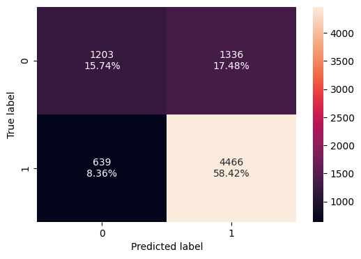

```python
# use a grid search to tune hyperparameters of Gradient Boosting model
# define the parameter grid
param_grid = {
    "init": [AdaBoostClassifier(random_state=1), DecisionTreeClassifier(random_state=1)],
    "n_estimators": np.arange(50, 110, 25),
    "learning_rate": [0.01, 0.1, 0.05],
    "subsample": [0.7, 0.9],
    "max_features": [0.5, 0.7, 1],
}

# initialize the Gradient Boost model
gb = GradientBoostingClassifier(random_state=1)

# set up grid search cv
gb_grid_search = GridSearchCV(
    estimator=gb, param_grid=param_grid, cv=5, n_jobs=-1, scoring="f1"
)

# fit the model
gb_grid_search.fit(X_train, y_train)

# print the best parameters
print("Best parameters found: ", gb_grid_search.best_params_)

# create a confusion matrix of the best parameters
confusion_matrix_sklearn(gb_best_estimator, X_test, y_test)

# calculating different metrics
gb_grid_search_train_perf = model_performance_classification_sklearn(
    gb_grid_search, X_train, y_train
)
print("Training performance:\n", gb_grid_search_train_perf)
gb_grid_search_test_perf = model_performance_classification_sklearn(
    gb_grid_search, X_test, y_test
)
print("Testing performance:\n", gb_grid_search_test_perf)
```

```
Best parameters found:  {'base_estimator': DecisionTreeClassifier(max_depth=3, random_state=1), 'learning_rate': 0.1, 'n_estimators': 50}
Training performance:
    Accuracy    Recall  Precision        F1
0   0.75314  0.888189   0.775051  0.827772
Testing performance:
    Accuracy    Recall  Precision        F1
0  0.740842  0.881881   0.765646  0.819663
```

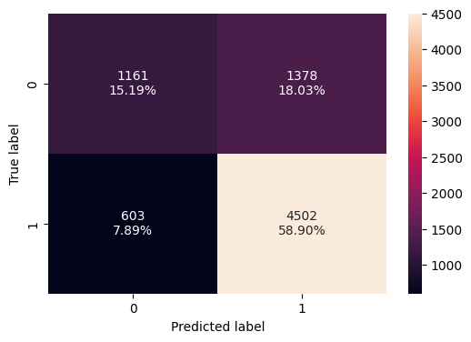

```python
# use a grid search to tune hyperparameters for AdaBoost
# define the parameter grid
param_grid = {
    "n_estimators": np.arange(50,110,25),
    "learning_rate": [0.01,0.1,0.05],
    "base_estimator": [
        DecisionTreeClassifier(max_depth=2, random_state=1),
        DecisionTreeClassifier(max_depth=3, random_state=1),
    ],
}

# initialize the AdaBoost model
ada = AdaBoostClassifier(random_state=1)

# set up grid search cv
ada_grid_search = GridSearchCV(
    estimator=ada, param_grid=param_grid, cv=5, n_jobs=-1, scoring="f1"
)

# fit the model
ada_grid_search.fit(X_train, y_train)

# print the best parameters
print("Best parameters found: ", ada_grid_search.best_params_)

# create a confusion matrix
confusion_matrix_sklearn(ada_grid_search, X_test, y_test)

# calculating different metrics
ada_grid_search_train_perf = model_performance_classification_sklearn(
    ada_grid_search, X_train, y_train
)
print("Training performance:\n", ada_grid_search_train_perf)
ada_grid_search_test_perf = model_performance_classification_sklearn(
    ada_grid_search, X_test, y_test
)
print("Testing performance:\n", ada_grid_search_test_perf)
```

```
Best parameters found:  {'max_features': 0.7, 'max_samples': 0.8, 'n_estimators': 70}
Training performance:
    Accuracy    Recall  Precision        F1
0  0.998318  0.999832   0.997655  0.998742
Testing performance:
    Accuracy    Recall  Precision        F1
0  0.728414  0.884035   0.752543  0.813007
```

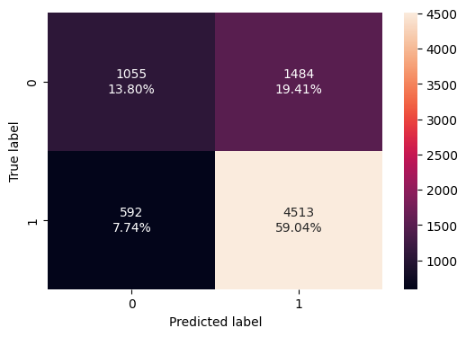

```python
# use a grid search to find the best hyperparameters for bagging classifier
# define the parameter grid
param_grid = {
    'max_samples': [0.8,0.9,1],
    'max_features': [0.7,0.8,0.9],
    'n_estimators' : [30,50,70],
}

# initialize the bagging classifier
bag = BaggingClassifier(random_state=1)

# set up grid search cv
bag_grid_search = GridSearchCV(
    estimator=bag, param_grid=param_grid, cv=5, n_jobs=-1, scoring="f1"
)

# fit the model
bag_grid_search.fit(X_train, y_train)

# print the best parameters
print("Best parameters found: ", bag_grid_search.best_params_)

# create a confusion matrix
confusion_matrix_sklearn(bag_grid_search, X_test, y_test)

# calculating different metrics
bag_grid_search_train_perf = model_performance_classification_sklearn(
    bag_grid_search, X_train, y_train)
print("Training performance:\n", bag_grid_search_train_perf)
bag_grid_search_test_perf = model_performance_classification_sklearn(
    bag_grid_search, X_test, y_test)
print("Testing performance:\n", bag_grid_search_test_perf)
```

```
Best parameters found:  {'max_features': 'sqrt', 'max_samples': 0.5, 'min_samples_leaf': 3, 'n_estimators': 110}
Training performance:
    Accuracy    Recall  Precision        F1
0  0.806571  0.914211   0.817704  0.863269
Testing performance:
    Accuracy    Recall  Precision        F1
0  0.743066  0.872282    0.77242  0.819319
```

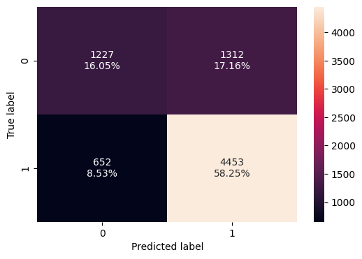

```python
# use a grid search to find the best hyperparameters for random forest
# define the parameter grid
param_grid = {
    "n_estimators": [50,110,25],
    "min_samples_leaf": np.arange(1, 4),
    "max_features": [np.arange(0.3, 0.6, 0.1),'sqrt'],
    "max_samples": np.arange(0.4, 0.7, 0.1)
}

# initialize the random forest classifier
rf = RandomForestClassifier(random_state=1)

# set up grid search cv
rf_grid_search = GridSearchCV(
    estimator=rf, param_grid=param_grid, cv=5, n_jobs=-1, scoring="f1"
)

# fit the model
rf_grid_search.fit(X_train, y_train)

# print the best parameters
print("Best parameters found: ", rf_grid_search.best_params_)

# create a confusion matrix
confusion_matrix_sklearn(rf_grid_search, X_test, y_test)

# calculating different metrics
rf_grid_search_train_perf = model_performance_classification_sklearn(
    rf_grid_search, X_train, y_train
)
print("Training performance:\n", rf_grid_search_train_perf)
rf_grid_search_test_perf = model_performance_classification_sklearn(
    rf_grid_search, X_test, y_test
)
print("Testing performance:\n", rf_grid_search_test_perf)
```

```
Best parameters found:  {'max_depth': 5, 'max_leaf_nodes': 15, 'min_impurity_decrease': 0.0001, 'min_samples_leaf': 1}
Training performance:
    Accuracy    Recall  Precision        F1
0  0.737834  0.916226   0.747961  0.823587
Testing performance:
    Accuracy    Recall  Precision        F1
0  0.728938  0.914006   0.740753  0.818309
```

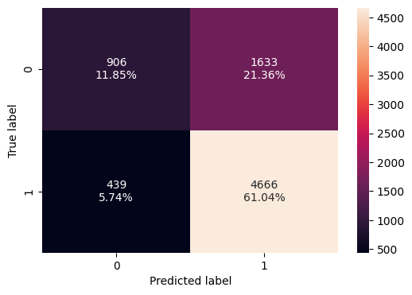

```python
# use a grid search to find the best hyperparameters for the decision tree
# define the parameter grid
param_grid = {
    'max_depth': np.arange(2,6),
    'min_samples_leaf': [1, 4, 7],
    'max_leaf_nodes' : [10, 15],
    'min_impurity_decrease': [0.0001,0.001]
}

# initialize the decision tree classifier
dtree= DecisionTreeClassifier(random_state=1)

# set up grid search cv
dtree_grid_search = GridSearchCV(
    estimator=dtree, param_grid=param_grid, cv=5, n_jobs=-1, scoring="f1"
)

# fit the model
dtree_grid_search.fit(X_train, y_train)

# print the best parameters
print("Best parameters found: ", dtree_grid_search.best_params_)

# create a confusion matrix
confusion_matrix_sklearn(dtree_grid_search, X_test, y_test)

# calculating different metrics
dtree_grid_search_train_perf = model_performance_classification_sklearn(
    dtree_grid_search, X_train, y_train
)
print("Training performance:\n", dtree_grid_search_train_perf)
dtree_grid_search_test_perf = model_performance_classification_sklearn(
    dtree_grid_search, X_test, y_test
)
print("Testing performance:\n", dtree_grid_search_test_perf)
```

```
Best parameters found:  {'gamma': 3, 'learning_rate': 0.05, 'n_estimators': 50, 'scale_pos_weight': 1, 'subsample': 0.9}
Training performance:
    Accuracy    Recall  Precision        F1
0  0.761101  0.891379   0.781613  0.832895
Testing performance:
    Accuracy    Recall  Precision        F1
0   0.74359  0.880118   0.769218  0.820939
```

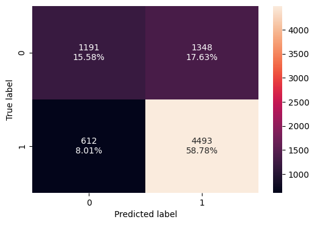

```python
# use a grid search to find the best parameters for XGBoost
# define the parameter grid
param_grid={'n_estimators':np.arange(50,110,25),
            'scale_pos_weight':[1,2,5],
            'learning_rate':[0.01,0.1,0.05],
            'gamma':[1,3],
            'subsample':[0.7,0.9]
}

# initialize the XGBoost classifier
XGB= XGBClassifier(random_state=1)

# set up grid search cv
XGB_grid_search = GridSearchCV(
    estimator=XGB, param_grid=param_grid, cv=5, n_jobs=-1, scoring="f1"
)

# fit the model
XGB_grid_search.fit(X_train, y_train)

# print the best parameters
print("Best parameters found: ", XGB_grid_search.best_params_)

# create a confusion matrix
confusion_matrix_sklearn(XGB_grid_search, X_test, y_test)

# calculating different metrics
XGB_grid_search_train_perf = model_performance_classification_sklearn(
    XGB_grid_search, X_train, y_train
)
print("Training performance:\n", XGB_grid_search_train_perf)
XGB_grid_search_test_perf = model_performance_classification_sklearn(
    XGB_grid_search, X_test, y_test
)
print("Testing performance:\n", XGB_grid_search_test_perf)
```

## Model Performance Comparison and Conclusions

```python
# let's compare all the models built so far
model_perf_comparison = pd.concat(
    [
        gb_model_test_perf.T,
        ada_model_test_perf.T,
        bag_model_test_perf.T,
        rf_model_test_perf.T,
        dtree_model_test_perf.T,
        XGB_model_test_perf.T,
        gb_grid_search_test_perf.T,
        ada_grid_search_test_perf.T,
        bag_grid_search_test_perf.T,
        rf_grid_search_test_perf.T,
        dtree_grid_search_test_perf.T,
        XGB_grid_search_test_perf.T,
     ],
    axis=1
)

model_perf_comparison.columns=[
    'Gradient Boost',
    'AdaBoost',
    'Bagging Classifier',
    'Random Forest',
    'Decision Tree',
    'XGBoost',
    'Gradient Boost Tuned',
    'AdaBoost Tuned',
    'Bagging Classifier Tuned',
    'Random Forest Tuned',
    'Decision Tree Tuned',
    'XGBoost Tuned',
]
print("Model Performance Comparison:")
model_perf_comparison
```

```
Model Performance Comparison:
```

|  | Gradient Boost | AdaBoost | Bagging Classifier | Random Forest | Decision Tree | XGBoost | Gradient Boost Tuned | AdaBoost Tuned | Bagging Classifier Tuned | Random Forest Tuned | Decision Tree Tuned | XGBoost Tuned |
| --- | --- | --- | --- | --- | --- | --- | --- | --- | --- | --- | --- | --- |
| Accuracy | 0.744767 | 0.732993 | 0.695709 | 0.720304 | 0.661695 | 0.728545 | 0.741627 | 0.740842 | 0.728414 | 0.743066 | 0.728938 | 0.743590 |
| Recall | 0.873457 | 0.885015 | 0.767091 | 0.831538 | 0.743389 | 0.855044 | 0.874829 | 0.881881 | 0.884035 | 0.872282 | 0.914006 | 0.880118 |
| Precision | 0.773595 | 0.756530 | 0.774985 | 0.768604 | 0.748373 | 0.765789 | 0.769735 | 0.765646 | 0.752543 | 0.772420 | 0.740753 | 0.769218 |
| F1 | 0.820499 | 0.815744 | 0.771018 | 0.798833 | 0.745873 | 0.807959 | 0.818924 | 0.819663 | 0.813007 | 0.819319 | 0.818309 | 0.820939 |

Gradient Boost vs Gradient Boost Tuned: very slight drop in f1 score (<1% decrease)

Ada Boost vs Ada Boost Tuned: very slight increase in f1 score (<1% increase)

Bagging Classifier vs Bagging Classifier Tuned: small increase in f1 score (4% increase)

Random Tree vs Random Tree Tuned: small increase in f1 score (2% increase)

Decision Tree vs Decision Tree Tuned: moderate increase in f1 score (7% increase)

XGBoost vs XGBoost Tuned: small increase in f1 score (1% increase)

The two models with the highest performance are Gradient Boost and XGBoost Tuned.

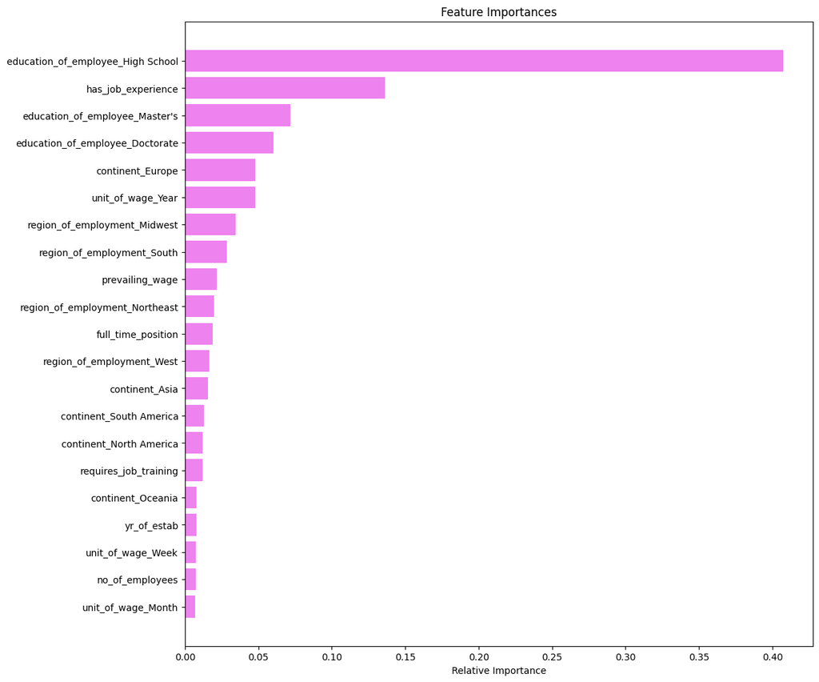

```python
# check the feature importance of the best model
best_model = XGB_grid_search.best_estimator_
feature_names = X_train.columns
importances = best_model.feature_importances_
indices = np.argsort(importances)

plt.figure(figsize=(12, 12))
plt.title('Feature Importances')
plt.barh(range(len(indices)), importances[indices], color='violet', align='center')
plt.yticks(range(len(indices)), [feature_names[i] for i in indices])
plt.xlabel('Relative Importance')
plt.show()
```

## Actionable Insights and Recommendations

Looking at the models above. We can predict with 82% f1 score how likely an applicant is to have their green card certified.

We can see that the most important features are:

- If they only have a high school education, that is a VERY STRONG indicator their visa WILL NOT be certified.
- If they have job experience, that is a STRONG indicator their visa WILL be certified.
- If they have a master's degree, that is a MODERATELY STRONG indicator their visa WILL be certified.
- If they have a doctorate, that is a MODERATELY STRONG indicator their visa WILL be certified.
- If they are from Europe, that is a MODERATELY STRONG indicator their visa WILL be certified.

We can see the least important features are the following:

- If the job has a Monthly Unit of Wage.
- The number of employees employed at the company.
- If the job has a Weekly Unit of Wage.
- The year the company was established.
- If the applicant is from the Oceania continent.

My recommendation is to gather more data. I would gather data by country of origin, if they speak English already, and the field of work they're applying for. It might be worth looking at race, age and gender, although this would be for the purpose of preventing discrimination.

Furthermore, If I was an HR employee, I would prioritize applicants with higher levels of education and job experience. (although I'm sure they already do this in most cases). What they might not expect is that Eurporean candidates seem to be stronger candidates overall based on the fact that they are selected at a noticably higher rate than candidates from other continents.

```python
shell jupyter nbconvert --to html '/content/drive/MyDrive/Python Foundations - GreatLearning/ENews_Express_Learner_Notebook_Full_Code.ipynb'
```